# L01 Visualization

### Exercise 3

Construct a scatterplot of `hwy` versus `cty`. Set the color of the points to `drv`.

Now construct a scatterplot of `hwy` versus `cty`. Set the color of the points to your favorite color (try typing `colors()` in the console) and `facet` by `drv`. Read `?facet_wrap` and adjust the `ncol` and `scales` as necessary.

**Solution**

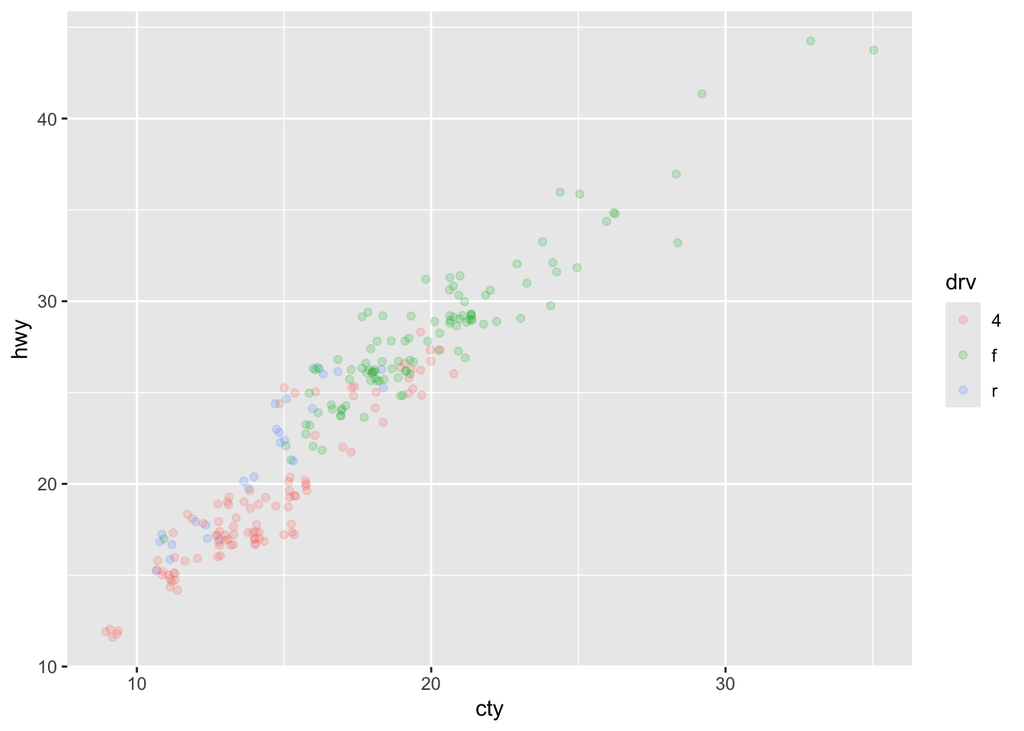

```r
ggplot(mpg, aes(x = cty, y = hwy, color = drv)) +
  geom_jitter(alpha = 0.2)
```

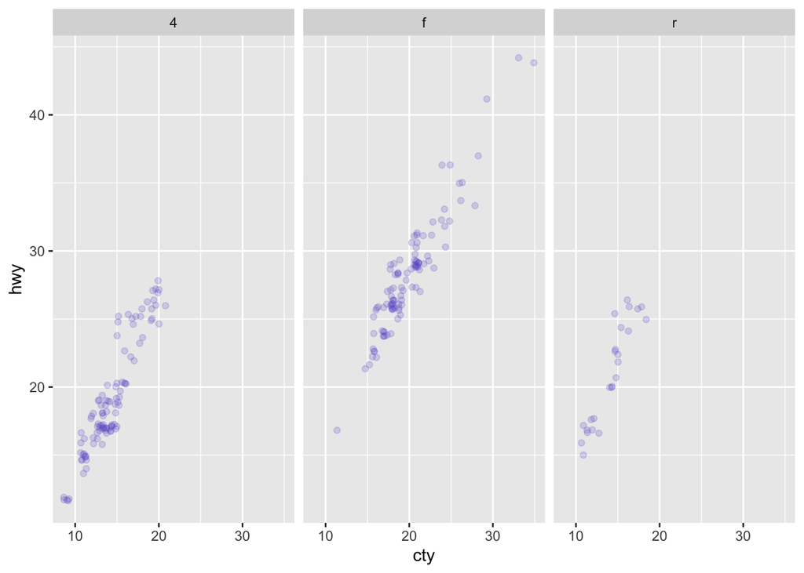

```r
ggplot(mpg, aes(x = cty, y = hwy)) +
  geom_jitter(alpha = 0.2, color = "slateblue") +
  facet_wrap(~drv)
```

What are the advantages to using faceting instead of the color aesthetic? What are the disadvantages? How might the balance change if you had a larger dataset?

**Solution**

Using too many aesthetic mappings can make a plot overly busy and cluttered. Using facets allows us to focus on subsets of the data rather than squishing all of that information into one graph. However, a larger dataset might become difficult to read, visually compressing any smaller differences and becoming cluttered with so many separate graphs.

### Exercise 4

Construct a scatterplot of `hwy` vs `cty`. Next, map a third numerical variable to `color`, then `size`, then `shape`.

**Solution**

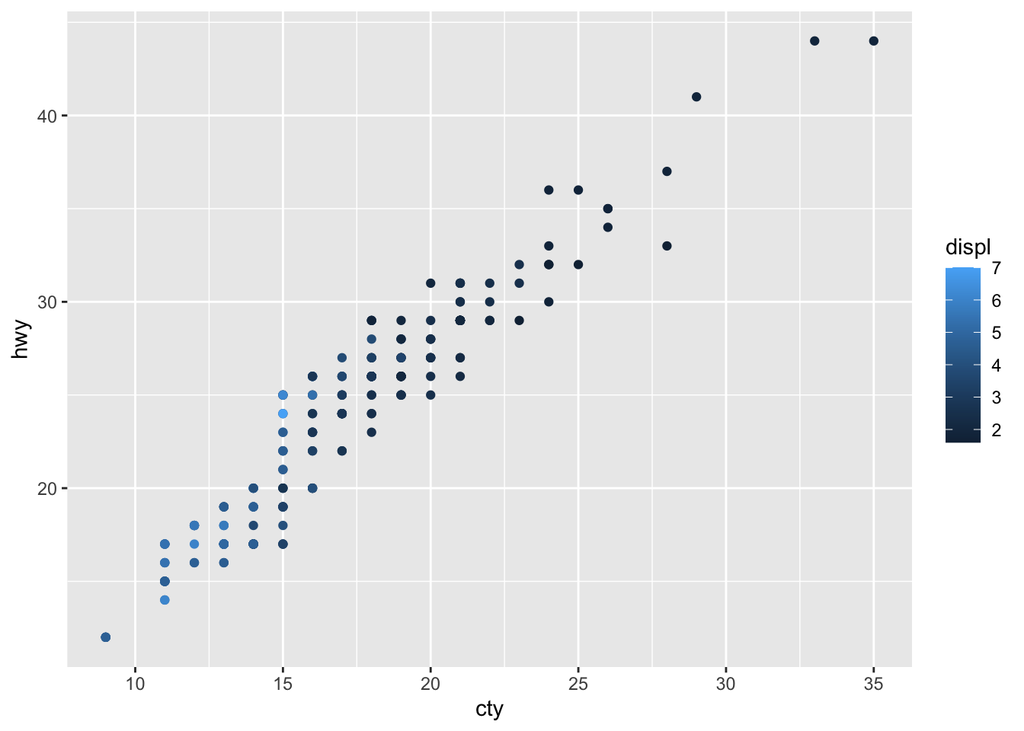

```r
# color
ggplot(mpg, aes(x = cty, y = hwy, color = displ)) +
  geom_point()
```

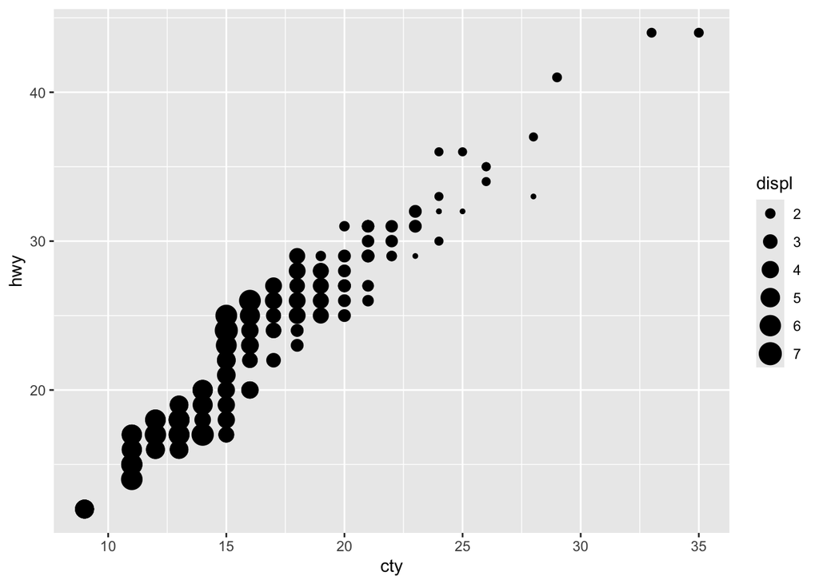

```r
# size
ggplot(mpg, aes(x = cty, y = hwy, size = displ)) +
  geom_point()
```

```r
# shape yields error because it is continuous
# ggplot(mpg, aes(x = cty, y = hwy, shape = displ)) +
#   geom_point()
```

The shape aesthetic doesn’t work with displ because displ is continous and there are a limited num of shapes.

How do the aesthetics behave differently for categorical versus numerical variables? In other words, which variable types (numeric/categorical) are appropriate to match to which aesthetics (size/shape/color)?

**Solution**

Shape does not work for continuous numeric data, because you would need an infinite number of shapes to represent the numbers. We can potentially avoid this problem using bins (?) Size and color may fluctuate on a gradient scale according to numeric data, or they can be discrete representations according to categorical data, but mapping categorical data onto something like size can get confusing.

Color can map both discrete and continuous variables, but shape can only map discrete (categorical), and size works best for continuous (numeric).

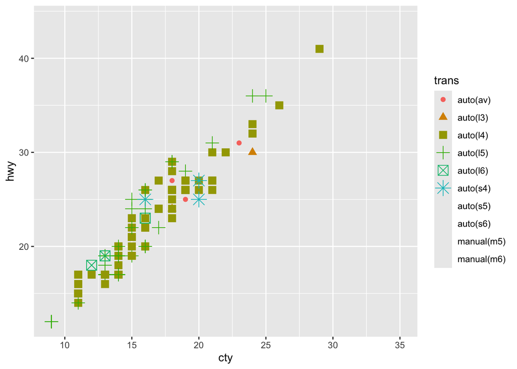

```r
# mapping  categorical
# shape = trans does not work well
ggplot(mpg, aes(x = cty,
                y = hwy,
                color = trans,
                shape = trans,
                size = trans)) +
  geom_point()
```

### Exercise 5

Construct a histogram of the `carat` variable in the `diamonds` dataset. Adjust the `bins` to an appropriate value. Add a `title`, remove the axis label that says `count`, and add a `caption`: “Source: ggplot2 package”.

**Solution**

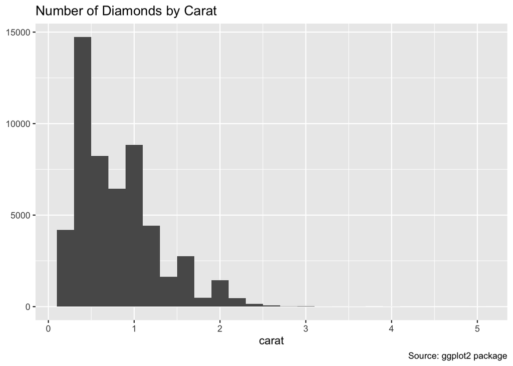

```r
ggplot(diamonds, aes(x = carat)) +
  geom_histogram(binwidth = 0.20) +
  labs(
    title = "Number of Diamonds by Carat",
    caption = "Source: ggplot2 package",
    y = NULL
  )
```

### Exercise 6

Construct 2 appropriate graphics to show the relationship between `carat` and `cut`.

**Solution**

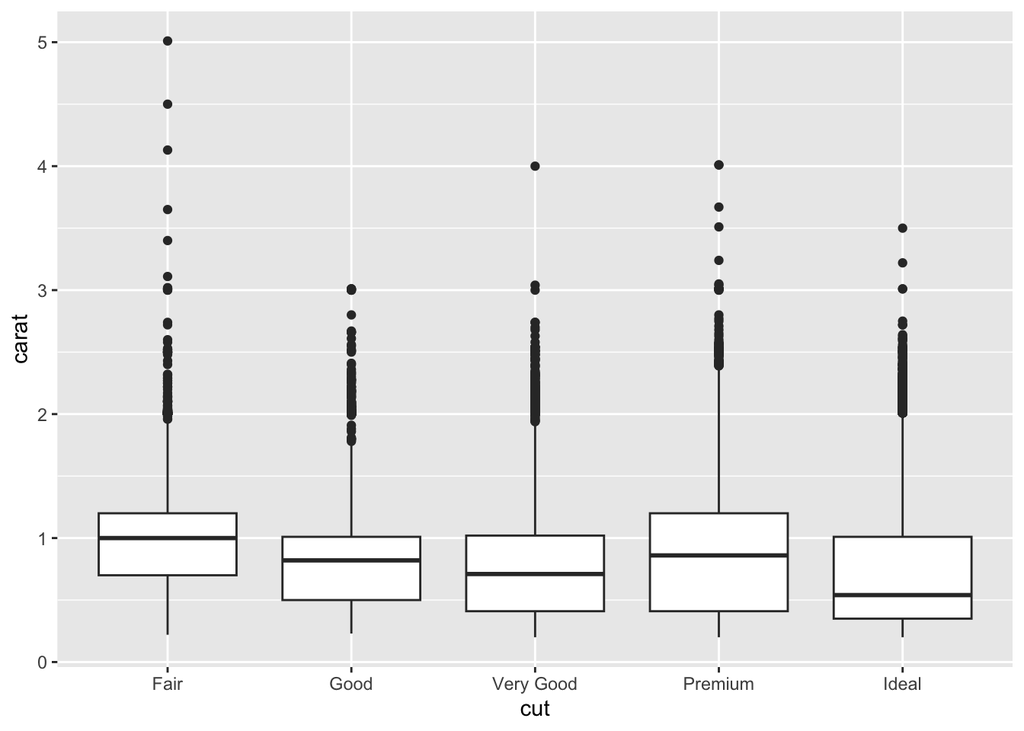

```r
ggplot(diamonds, aes(x = cut, y = carat)) +
  geom_boxplot()
```

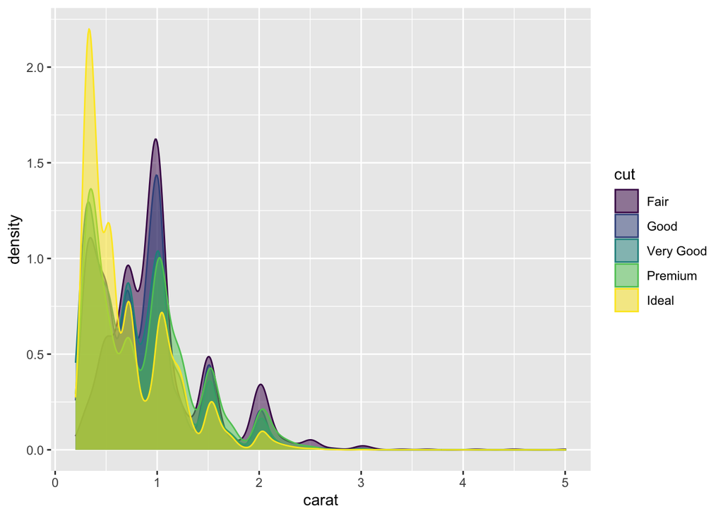

```r
ggplot(diamonds, aes(x = carat, color = cut, fill = cut)) +
  geom_density(alpha = 0.5)
```

### Exercise 7

Construct a barplot of `cut`. Add in `aes(fill = carat > 0.7)`.

**Solution**

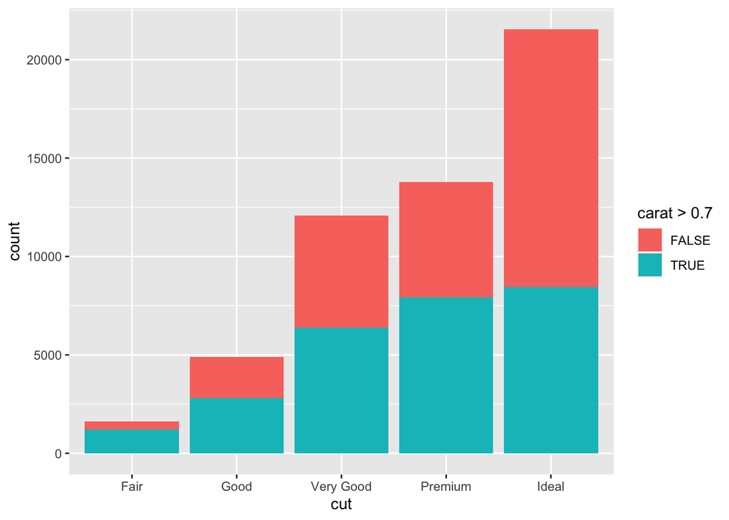

```r
# did not use position = "fill" because I still wanted to see total count #
ggplot(diamonds, aes(x = cut, fill = carat > 0.7)) +
  geom_bar()
```

### Exercise 8

When would you use `facet_grid()` versus `facet_wrap()`? When using `facet_grid()` it is suggested that you put the variable with more unique levels in the columns. Why do you think that this practice is suggested?

**Solution**

‘facet_grid()’ is most useful with two discrete variables. One variable with many levels works better with ‘facet_wrap()’. I think putting the variable with more unique levels in the columns is related to scale, as the more unique levels one variable has, the more “empty space” will be present in the other variable’s graphical space.

## Case Study

Congratulations, you just landed your first job as a data analyst for Tinder! The dataset is stored in the `data` folder called `tinder_data`. A codebook, `tinder_data_codebook.csv`, provides a description of each of the variable names. This has been read in for you at the top of the document. We will learn more about importing data later in the quarter.

**Your first assignment is to determine if there is a relationship between messages sent and messages received and how this differs based on user gender.** Your boss has asked for a one paragraph summary with graphics to support your conclusions. Your boss wants all graphics *saved* into a folder named “plots”. Hint: `ggsave()`.

Since this is your first project as a data analyst you have been provided some tips and considerations for getting started:

- When approaching a research question it is important to use univariate, bivariate, and multivariate analysis (depending on the problem) to get a better understanding of your data and also identify any potential problems.
- How might the distribution of your variables impact your conclusions? Outliers? Weird values? Imbalanced classes?
- How might `coord_fixed()` and `geom_abline()` improve a graphic?
- Feel free to be creative! It is your job to answer this question and interpret conclusions in the most appropriate ways you see fit.

This dataset was provided by [Swipestats.io](https://www.swipestats.io/).

**Solution**

Comparing messages sent to messages received, we see a pretty positive linear relationship. However, there is a lot more to the story.

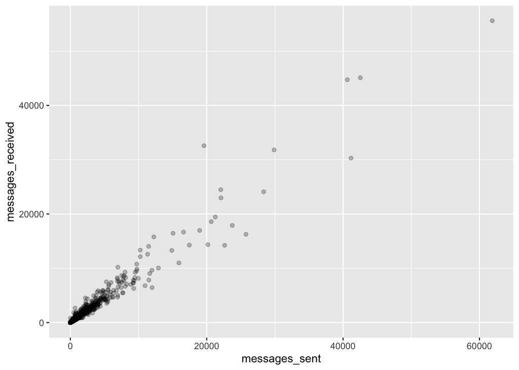

Simply separating by gender, we see that many of the larger outliers appear to be male.

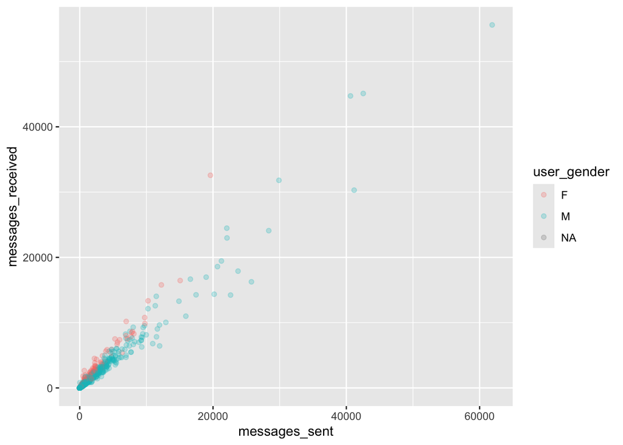

We can try to view these differences more easily by making separate visuals per gender. Here, we can find a little more clarity between gender category.

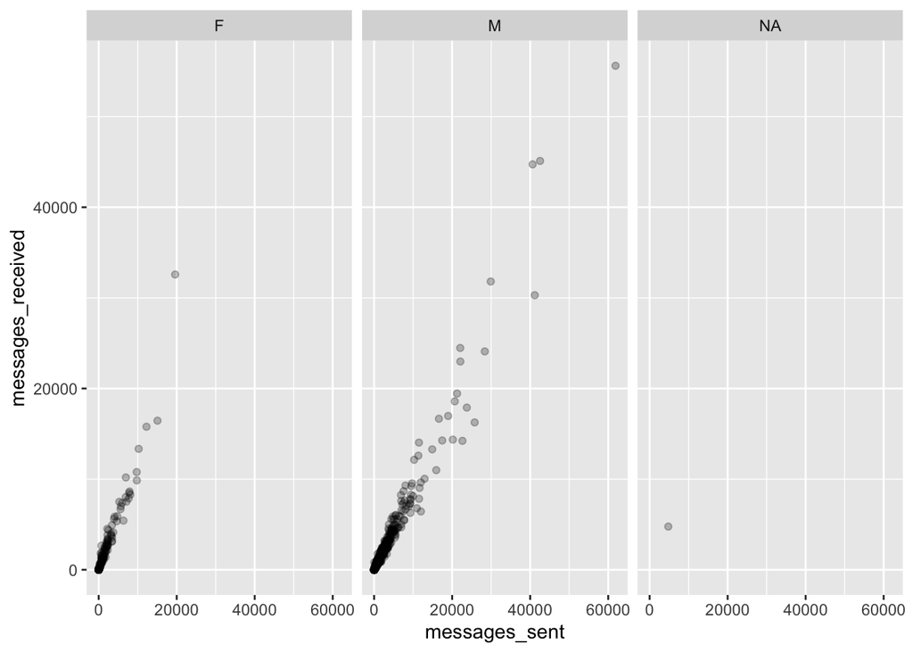

In general, this final plot demonstrates that the more messages someone sends, the more they receive, but that a higher number of male users send and receive more messages, while female users send and receive less total. Trendlines show a potential higher ratio of received to sent messages by female users, meaning that female users who send a certain number of messages may receive slightly more messages than male users sending the same amount. However, these trendlines are both influenced by outliers, and further investigation of gender interest, conversation length, and rate of ghosting will be useful.

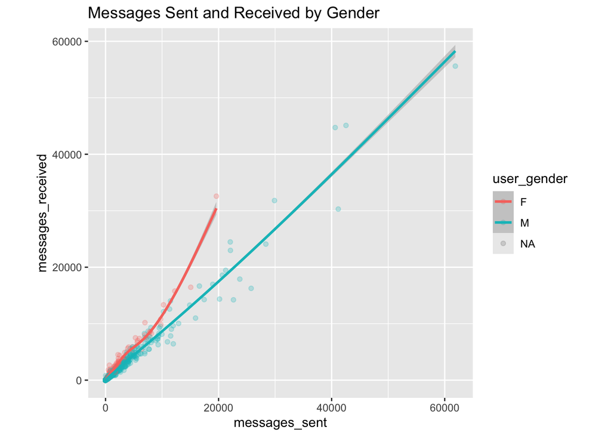

## Graduate Challenge

**Important**

Graduate students are required to complete this challenge. **It is optional for undergraduate students.**

- alpha = 0.25
- theme is with Google Docs Chart from [ggthemes package](https://jrnold.github.io/ggthemes/reference/index.html).